# 1 - Cellxgene Census

Author

CDN team

Published

March 1, 2024

## Introduction

Welcome! welcome neighbors, welcome newcomers, welcome experts and enthusiasts, welcome to all who share a fascination with the building blocks of life. Here in the world of single-cell analysis, we come together as a community, eager to share and learn together, and to marvel at cellular wonders at the scale of RNA. Whether your journey here was driven by professional passion, academic ambition, or curiosity, whether you wield a pipette, a stethoscope, or a laptop, you’ve found your tribe. At this workshop, we will delve into the secret lives of cells, and hopefully we will discover not just the secrets they hold, but the connections that hold them together.

In this first analysis notebook of our workshop, we will download an example dataset from a public repository of single cell data to give us common ground as we explore methods for understanding single cells. Cellxgene Census is a package run by the Chan Zuckerberg Initiative in collaboration with tileDB, making it the fastest way to download single-cell data from the web.

## Libraries

```r
library(tidyverse)
library(cellxgene.census)
library(gganatogram)
library(gridExtra)
```

## Set up and run an example cellxgene census query

```r
census <- open_soma()
census_hsapiens_metadata <-  census$get("census_data")$get("homo_sapiens")$get("obs")

# Read cell metadata from census using queries
metadata_query <-  census_hsapiens_metadata$read(
#    value_filter = "sex == 'female' & cell_type %in% c('microglial cell', 'macrophage')", - you can also filter by cell type
   column_names = c("dataset_id", "assay", "cell_type", "sex", "tissue", "tissue_general", "suspension_type", "disease", "donor_id")
)

# For a list of possible metadata columns, run the following:
# census_hsapiens_metadata$colnames()

# Queries are in a special query format which needs to be processed using cellxgene functions
cell_metadata <-  metadata_query$concat()

# Convert the processed object to an R data.frame to enable us to visualize numbers
cell_metadata <-  as.data.frame(cell_metadata)

print(cell_metadata %>% head)
```

```
                            dataset_id        assay                        cell_type  sex                tissue tissue_general suspension_type disease  donor_id
1 2bdd3a2c-2ff4-4314-adf3-8a06b797a33a Smart-seq v4                  oligodendrocyte male middle temporal gyrus          brain         nucleus  normal H200.1030
2 2bdd3a2c-2ff4-4314-adf3-8a06b797a33a Smart-seq v4   oligodendrocyte precursor cell male middle temporal gyrus          brain         nucleus  normal H200.1030
3 2bdd3a2c-2ff4-4314-adf3-8a06b797a33a Smart-seq v4 astrocyte of the cerebral cortex male middle temporal gyrus          brain         nucleus  normal H200.1030
4 2bdd3a2c-2ff4-4314-adf3-8a06b797a33a Smart-seq v4 astrocyte of the cerebral cortex male middle temporal gyrus          brain         nucleus  normal H200.1030
5 2bdd3a2c-2ff4-4314-adf3-8a06b797a33a Smart-seq v4 astrocyte of the cerebral cortex male middle temporal gyrus          brain         nucleus  normal H200.1030
6 2bdd3a2c-2ff4-4314-adf3-8a06b797a33a Smart-seq v4   oligodendrocyte precursor cell male middle temporal gyrus          brain         nucleus  normal H200.1030
```

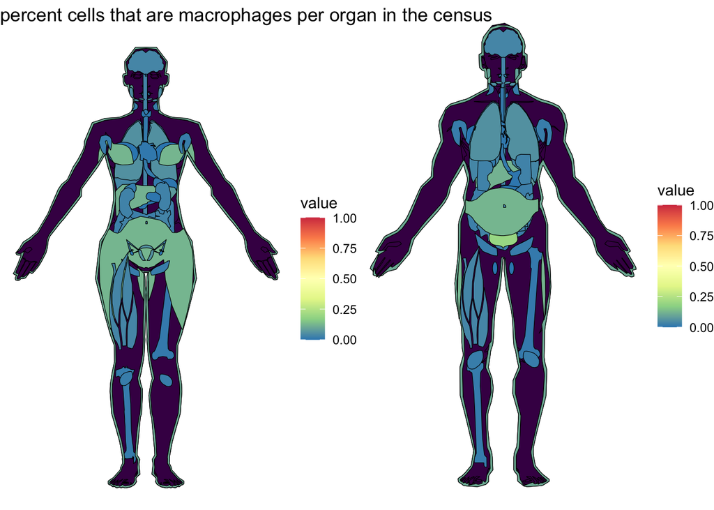

```r
organdf <- cell_metadata

organdf$organ <- corrections[match(organdf$tissue_general,corrections$census),]$anatogram
organdf$organ <- ifelse(is.na(organdf$organ),organdf$tissue_general,organdf$organ)

organdf <- organdf %>% count(organ,cell_type)

organdf <- organdf %>% left_join(
                        organdf %>% filter(cell_type %in% c('microglial cell','macrophage')) %>%
                        select(organ, n) %>%
                        group_by(organ) %>%
                        summarize(macrophage_count = sum(n))
                        )

organdf <- organdf %>% group_by(organ) %>%
                       summarize(cell_type,n,macrophage_count,total_cell_count=sum(n))

organdf <- organdf %>% group_by(organ) %>% mutate(macrophage_pct = macrophage_count/total_cell_count)

macF <- gganatogram(data=hgFemale_key %>% left_join(organdf) %>%
                                  mutate(value=macrophage_pct) %>%
                                  select(-cell_type,-n) %>%
                                  distinct,
                                  fillOutline='#440154FF', organism='human',
                                  sex='female', fill="value") +
                                  scale_fill_distiller(palette='Spectral',limits=c(0,1)) +
                                  theme_void() +
                                  ggtitle('percent cells that are macrophages per organ in the census')

macM <- gganatogram(data=hgMale_key %>% left_join(organdf) %>%
                                  mutate(value=macrophage_pct) %>%
                                  select(-cell_type,-n) %>%
                                  distinct,
                                  fillOutline='#440154FF', organism='human',
                                  sex='male', fill="value") +
                                  theme_void() +
                                  scale_fill_distiller(palette='Spectral',limits=c(0,1))

grid.arrange(macF,macM, ncol=2)
```

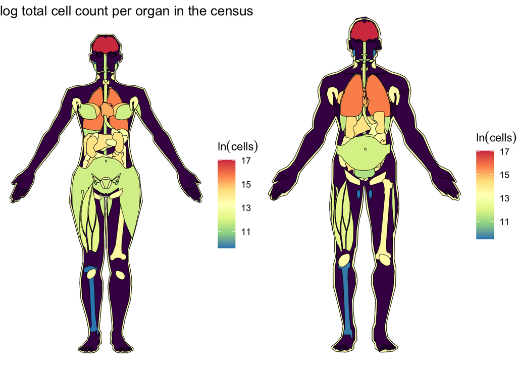

```r
totF <- gganatogram(data=hgFemale_key %>% left_join(organdf) %>%
                                  mutate(value=log(total_cell_count)) %>%
                                  select(-cell_type,-n) %>%
                                  distinct,
                                  fillOutline='#440154FF', organism='human',
                                  sex='female', fill="value") +
                                  scale_fill_distiller(palette='Spectral') +
                                  theme_void() +
                                  ggtitle('log total cell count per organ in the census') +
                                  labs(fill = expression(ln("cells")))

totM <- gganatogram(data=hgMale_key %>% left_join(organdf) %>%
                                  mutate(value=log(total_cell_count)) %>%
                                  select(-cell_type,-n) %>%
                                  distinct,
                                  fillOutline='#440154FF', organism='human',
                                  sex='male', fill="value") +
                                  theme_void() +
                                  scale_fill_distiller(palette='Spectral') +
                                  labs(fill = expression(ln("cells")))

grid.arrange(totF,totM, ncol=2)
```

## Querying datasets

Cellxgene Census also offers dataset-level metadata in the “census_info” rather than “census_data”.

```r
census_datasets <-  census$get("census_info")$get("datasets")
census_datasets <- census_datasets$read()$concat()
datasetsdf <- as.data.frame(census_datasets)
```

Looking at what’s available in the census, we see there is a collection DOI and a dataset title that might help us find datasets we are interested in. Since dataset titles often have special characters, I often collect DOIs in large tables for meta-analysis, and use these to obtain links to all the datasets I’m interested in.

```r
example_meta_analysis <- c('10.1016/j.jcmgh.2022.02.007', # a study of the colon epithelium
                            '10.1126/science.abl4896') # tabula sapiens, which has many datasets across tissues

datasets <- datasetsdf %>% filter(collection_doi %in% example_meta_analysis) %>% arrange(collection_doi)
print(datasets %>% head)
```

```
  soma_joinid                        collection_id                                                                                                        collection_name              collection_doi                           dataset_id                   dataset_version_id                             …
1         193 64b24fda-6591-4ce1-89e7-33eb6c43ad7b A proximal-to-distal survey of healthy adult human small intestine and colon epithelium by single-cell transcriptomics 10.1016/j.jcmgh.2022.02.007 019c7af2-c827-4454-9970-44d5e39ce068 153ddfb5-c677-47fd-b584-7f9157fca6b3 A proximal-to-distal survey …
2          63 e5f58829-1a66-40b5-a624-9046778e74f5                                                                                                         Tabula Sapiens     10.1126/science.abl4896 ff45e623-7f5f-46e3-b47d-56be0341f66b 0b29f4ce-5e72-4356-b74b-b54714979234                             …
3          64 e5f58829-1a66-40b5-a624-9046778e74f5                                                                                                         Tabula Sapiens     10.1126/science.abl4896 f01bdd17-4902-40f5-86e3-240d66dd2587 bd13c169-af97-4d8f-ba45-7588808c2e48                             …
4          65 e5f58829-1a66-40b5-a624-9046778e74f5                                                                                                         Tabula Sapiens     10.1126/science.abl4896 e6a11140-2545-46bc-929e-da243eed2cae 47615a3d-0a9f-4a78-88ef-5cce2a84637d                             …
5          66 e5f58829-1a66-40b5-a624-9046778e74f5                                                                                                         Tabula Sapiens     10.1126/science.abl4896 e5c63d94-593c-4338-a489-e1048599e751 ac7714f0-dce2-40ba-9912-324de6c9a77f                             …
6          67 e5f58829-1a66-40b5-a624-9046778e74f5                                                                                                         Tabula Sapiens     10.1126/science.abl4896 d8732da6-8d1d-42d9-b625-f2416c30054b f849902f-42a8-48a6-9e01-b07727951428                             …
```

```r
# we can use dataset's dataset_id to gather cell metadata from the census
meta_analysis <- cell_metadata %>% filter(dataset_id %in% datasets$dataset_id)
# and peruse all the celltypes that are found in these datasets or plot some statistics
print(meta_analysis %>% head)
```

```
                            dataset_id     assay              cell_type  sex            tissue tissue_general suspension_type disease donor_id
1 ff45e623-7f5f-46e3-b47d-56be0341f66b 10x 3' v3 pancreatic acinar cell male exocrine pancreas       pancreas            cell  normal     TSP9
2 ff45e623-7f5f-46e3-b47d-56be0341f66b 10x 3' v3                 T cell male exocrine pancreas       pancreas            cell  normal     TSP9
3 ff45e623-7f5f-46e3-b47d-56be0341f66b 10x 3' v3       endothelial cell male exocrine pancreas       pancreas            cell  normal     TSP9
4 ff45e623-7f5f-46e3-b47d-56be0341f66b 10x 3' v3 pancreatic acinar cell male exocrine pancreas       pancreas            cell  normal     TSP9
5 ff45e623-7f5f-46e3-b47d-56be0341f66b 10x 3' v3       endothelial cell male exocrine pancreas       pancreas            cell  normal     TSP9
6 ff45e623-7f5f-46e3-b47d-56be0341f66b 10x 3' v3           myeloid cell male exocrine pancreas       pancreas            cell  normal     TSP9
```

Sometimes we don’t have a list of datasets, but we want to know all the datasets that are available that contain data of samples coming from patients with a certain disease. We can use the census for this as well. One thing we might want to do is to find out how many patients were sampled across all those studies.

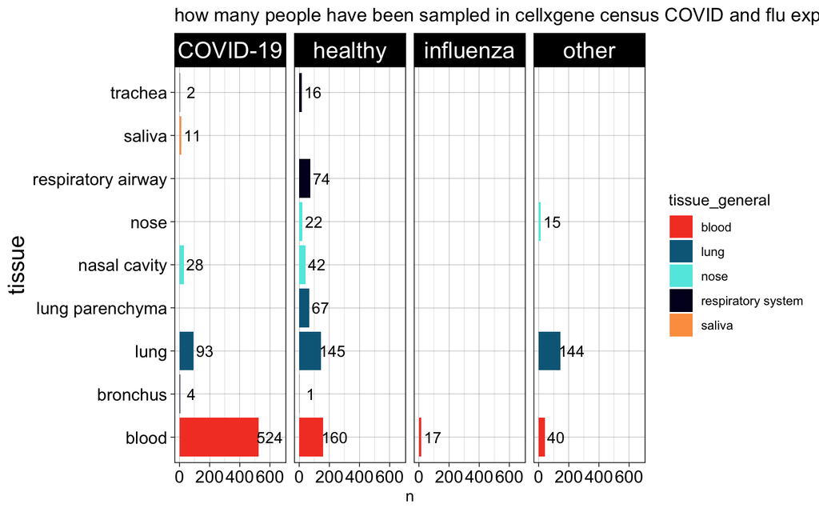

```r
cough_datasets <- cell_metadata %>% filter(disease %in% c("COVID-19",'influenza')) %>%
                pull(dataset_id)

sample_counts <- cell_metadata %>% filter(dataset_id %in% cough_datasets) %>%
                select(tissue_general,tissue,disease,donor_id) %>% distinct %>% # keep only one row per patient
                mutate(disease = ifelse(disease == 'COVID-19','COVID-19', # convert all disease names except covid, flu, and healthy to other
                                        ifelse(disease=='influenza','influenza',
                                                ifelse(disease=='normal','healthy','other')))) %>%
                count(tissue_general,tissue,disease)

p <- sample_counts %>% ggplot(aes(x=n, y=tissue, fill = tissue_general)) +
    geom_bar(stat='identity') +
    geom_text(aes(label=n),nudge_x=75) +
    facet_grid(. ~ disease) + theme_linedraw() +
    theme(strip.text.y=element_text(size=16),
          strip.text.x=element_text(size=16),
          axis.text.y=element_text(size=12),
          axis.text.x=element_text(size=12),
          axis.title.y=element_text(size=16),
         ) +
    scale_fill_manual(values = c('#F4442E','#086788','#61E8E1','#020122','#FC9E4F')) +
    expand_limits(x=c(0,675)) + # allow for room for n donor text
    ggtitle('how many people have been sampled in cellxgene census COVID and flu experiments?')

p
```

## Downloading count matrices

The following dataset isn’t actually included in cellxgene_census yet. I’ve opened a github issue with them to ask them if there’s a reason why ~half of the datasets in the Discovery portal aren’t included yet. Here is a link to our dataset of choice. Download it to your favorite compute environment.

[Workshop Dataset](https://cellxgene.cziscience.com/collections/4f889ffc-d4bc-4748-905b-8eb9db47a2ed)

Finally, we must close the census.

```r
census$close()
```